# Forcast the Sale Price of a House

## Understanding dataset

### Through the data

```python
import pandas as pd
import numpy as np
import matplotlib.pyplot as plt
%matplotlib inline
import seaborn as sns
```

```python
df=pd.read_csv("train.csv")
```

```python
df.shape
```

```
(1460, 81)
```

```python
pd.set_option('display.max_columns', None)
df.head()
```

|  | Id | MSSubClass | MSZoning | LotFrontage | LotArea | Street | Alley | LotShape | LandContour | Utilities | LotConfig | LandSlope | Neighborhood | Condition1 | Condition2 | BldgType | HouseStyle | OverallQual | OverallCond | YearBuilt | YearRemodAdd | RoofStyle | RoofMatl | Exterior1st | Exterior2nd | MasVnrType | MasVnrArea | ExterQual | ExterCond | … |
| --- | --- | --- | --- | --- | --- | --- | --- | --- | --- | --- | --- | --- | --- | --- | --- | --- | --- | --- | --- | --- | --- | --- | --- | --- | --- | --- | --- | --- | --- | --- |
| 0 | 1 | 60 | RL | 65.0 | 8450 | Pave | NaN | Reg | Lvl | AllPub | Inside | Gtl | CollgCr | Norm | Norm | 1Fam | 2Story | 7 | 5 | 2003 | 2003 | Gable | CompShg | VinylSd | VinylSd | BrkFace | 196.0 | Gd | TA | … |
| 1 | 2 | 20 | RL | 80.0 | 9600 | Pave | NaN | Reg | Lvl | AllPub | FR2 | Gtl | Veenker | Feedr | Norm | 1Fam | 1Story | 6 | 8 | 1976 | 1976 | Gable | CompShg | MetalSd | MetalSd | None | 0.0 | TA | TA | … |
| 2 | 3 | 60 | RL | 68.0 | 11250 | Pave | NaN | IR1 | Lvl | AllPub | Inside | Gtl | CollgCr | Norm | Norm | 1Fam | 2Story | 7 | 5 | 2001 | 2002 | Gable | CompShg | VinylSd | VinylSd | BrkFace | 162.0 | Gd | TA | … |
| 3 | 4 | 70 | RL | 60.0 | 9550 | Pave | NaN | IR1 | Lvl | AllPub | Corner | Gtl | Crawfor | Norm | Norm | 1Fam | 2Story | 7 | 5 | 1915 | 1970 | Gable | CompShg | Wd Sdng | Wd Shng | None | 0.0 | TA | TA | … |
| 4 | 5 | 60 | RL | 84.0 | 14260 | Pave | NaN | IR1 | Lvl | AllPub | FR2 | Gtl | NoRidge | Norm | Norm | 1Fam | 2Story | 8 | 5 | 2000 | 2000 | Gable | CompShg | VinylSd | VinylSd | BrkFace | 350.0 | Gd | TA | … |

```python
df.dtypes
```

```
Id                 int64
MSSubClass         int64
MSZoning          object
LotFrontage      float64
LotArea            int64
                  ...
MoSold             int64
YrSold             int64
SaleType          object
SaleCondition     object
SalePrice          int64
Length: 81, dtype: object
```

```python
df.describe().T
```

|  | count | mean | std | min | 25% | 50% | 75% | max |
| --- | --- | --- | --- | --- | --- | --- | --- | --- |
| Id | 1460.0 | 730.500000 | 421.610009 | 1.0 | 365.75 | 730.5 | 1095.25 | 1460.0 |
| MSSubClass | 1460.0 | 56.897260 | 42.300571 | 20.0 | 20.00 | 50.0 | 70.00 | 190.0 |
| LotFrontage | 1201.0 | 70.049958 | 24.284752 | 21.0 | 59.00 | 69.0 | 80.00 | 313.0 |
| LotArea | 1460.0 | 10516.828082 | 9981.264932 | 1300.0 | 7553.50 | 9478.5 | 11601.50 | 215245.0 |
| OverallQual | 1460.0 | 6.099315 | 1.382997 | 1.0 | 5.00 | 6.0 | 7.00 | 10.0 |
| OverallCond | 1460.0 | 5.575342 | 1.112799 | 1.0 | 5.00 | 5.0 | 6.00 | 9.0 |
| YearBuilt | 1460.0 | 1971.267808 | 30.202904 | 1872.0 | 1954.00 | 1973.0 | 2000.00 | 2010.0 |
| YearRemodAdd | 1460.0 | 1984.865753 | 20.645407 | 1950.0 | 1967.00 | 1994.0 | 2004.00 | 2010.0 |
| MasVnrArea | 1452.0 | 103.685262 | 181.066207 | 0.0 | 0.00 | 0.0 | 166.00 | 1600.0 |
| BsmtFinSF1 | 1460.0 | 443.639726 | 456.098091 | 0.0 | 0.00 | 383.5 | 712.25 | 5644.0 |
| BsmtFinSF2 | 1460.0 | 46.549315 | 161.319273 | 0.0 | 0.00 | 0.0 | 0.00 | 1474.0 |
| BsmtUnfSF | 1460.0 | 567.240411 | 441.866955 | 0.0 | 223.00 | 477.5 | 808.00 | 2336.0 |
| TotalBsmtSF | 1460.0 | 1057.429452 | 438.705324 | 0.0 | 795.75 | 991.5 | 1298.25 | 6110.0 |
| 1stFlrSF | 1460.0 | 1162.626712 | 386.587738 | 334.0 | 882.00 | 1087.0 | 1391.25 | 4692.0 |
| 2ndFlrSF | 1460.0 | 346.992466 | 436.528436 | 0.0 | 0.00 | 0.0 | 728.00 | 2065.0 |
| LowQualFinSF | 1460.0 | 5.844521 | 48.623081 | 0.0 | 0.00 | 0.0 | 0.00 | 572.0 |
| GrLivArea | 1460.0 | 1515.463699 | 525.480383 | 334.0 | 1129.50 | 1464.0 | 1776.75 | 5642.0 |
| BsmtFullBath | 1460.0 | 0.425342 | 0.518911 | 0.0 | 0.00 | 0.0 | 1.00 | 3.0 |
| BsmtHalfBath | 1460.0 | 0.057534 | 0.238753 | 0.0 | 0.00 | 0.0 | 0.00 | 2.0 |
| FullBath | 1460.0 | 1.565068 | 0.550916 | 0.0 | 1.00 | 2.0 | 2.00 | 3.0 |
| HalfBath | 1460.0 | 0.382877 | 0.502885 | 0.0 | 0.00 | 0.0 | 1.00 | 2.0 |
| BedroomAbvGr | 1460.0 | 2.866438 | 0.815778 | 0.0 | 2.00 | 3.0 | 3.00 | 8.0 |
| KitchenAbvGr | 1460.0 | 1.046575 | 0.220338 | 0.0 | 1.00 | 1.0 | 1.00 | 3.0 |
| TotRmsAbvGrd | 1460.0 | 6.517808 | 1.625393 | 2.0 | 5.00 | 6.0 | 7.00 | 14.0 |
| Fireplaces | 1460.0 | 0.613014 | 0.644666 | 0.0 | 0.00 | 1.0 | 1.00 | 3.0 |
| GarageYrBlt | 1379.0 | 1978.506164 | 24.689725 | 1900.0 | 1961.00 | 1980.0 | 2002.00 | 2010.0 |
| GarageCars | 1460.0 | 1.767123 | 0.747315 | 0.0 | 1.00 | 2.0 | 2.00 | 4.0 |
| GarageArea | 1460.0 | 472.980137 | 213.804841 | 0.0 | 334.50 | 480.0 | 576.00 | 1418.0 |
| WoodDeckSF | 1460.0 | 94.244521 | 125.338794 | 0.0 | 0.00 | 0.0 | 168.00 | 857.0 |
| OpenPorchSF | 1460.0 | 46.660274 | 66.256028 | 0.0 | 0.00 | 25.0 | 68.00 | 547.0 |
| EnclosedPorch | 1460.0 | 21.954110 | 61.119149 | 0.0 | 0.00 | 0.0 | 0.00 | 552.0 |
| 3SsnPorch | 1460.0 | 3.409589 | 29.317331 | 0.0 | 0.00 | 0.0 | 0.00 | 508.0 |
| ScreenPorch | 1460.0 | 15.060959 | 55.757415 | 0.0 | 0.00 | 0.0 | 0.00 | 480.0 |
| PoolArea | 1460.0 | 2.758904 | 40.177307 | 0.0 | 0.00 | 0.0 | 0.00 | 738.0 |
| MiscVal | 1460.0 | 43.489041 | 496.123024 | 0.0 | 0.00 | 0.0 | 0.00 | 15500.0 |
| MoSold | 1460.0 | 6.321918 | 2.703626 | 1.0 | 5.00 | 6.0 | 8.00 | 12.0 |
| YrSold | 1460.0 | 2007.815753 | 1.328095 | 2006.0 | 2007.00 | 2008.0 | 2009.00 | 2010.0 |
| SalePrice | 1460.0 | 180921.195890 | 79442.502883 | 34900.0 | 129975.00 | 163000.0 | 214000.00 | 755000.0 |

```python
df.describe().T.count()
```

```
count    38
mean     38
std      38
min      38
25%      38
50%      38
75%      38
max      38
dtype: int64
```

```python
df.describe(include='object').T
```

|  | count | unique | top | freq |
| --- | --- | --- | --- | --- |
| MSZoning | 1460 | 5 | RL | 1151 |
| Street | 1460 | 2 | Pave | 1454 |
| Alley | 91 | 2 | Grvl | 50 |
| LotShape | 1460 | 4 | Reg | 925 |
| LandContour | 1460 | 4 | Lvl | 1311 |
| Utilities | 1460 | 2 | AllPub | 1459 |
| LotConfig | 1460 | 5 | Inside | 1052 |
| LandSlope | 1460 | 3 | Gtl | 1382 |
| Neighborhood | 1460 | 25 | NAmes | 225 |
| Condition1 | 1460 | 9 | Norm | 1260 |
| Condition2 | 1460 | 8 | Norm | 1445 |
| BldgType | 1460 | 5 | 1Fam | 1220 |
| HouseStyle | 1460 | 8 | 1Story | 726 |
| RoofStyle | 1460 | 6 | Gable | 1141 |
| RoofMatl | 1460 | 8 | CompShg | 1434 |
| Exterior1st | 1460 | 15 | VinylSd | 515 |
| Exterior2nd | 1460 | 16 | VinylSd | 504 |
| MasVnrType | 1452 | 4 | None | 864 |
| ExterQual | 1460 | 4 | TA | 906 |
| ExterCond | 1460 | 5 | TA | 1282 |
| Foundation | 1460 | 6 | PConc | 647 |
| BsmtQual | 1423 | 4 | TA | 649 |
| BsmtCond | 1423 | 4 | TA | 1311 |
| BsmtExposure | 1422 | 4 | No | 953 |
| BsmtFinType1 | 1423 | 6 | Unf | 430 |
| BsmtFinType2 | 1422 | 6 | Unf | 1256 |
| Heating | 1460 | 6 | GasA | 1428 |
| HeatingQC | 1460 | 5 | Ex | 741 |
| CentralAir | 1460 | 2 | Y | 1365 |
| Electrical | 1459 | 5 | SBrkr | 1334 |
| KitchenQual | 1460 | 4 | TA | 735 |
| Functional | 1460 | 7 | Typ | 1360 |
| FireplaceQu | 770 | 5 | Gd | 380 |
| GarageType | 1379 | 6 | Attchd | 870 |
| GarageFinish | 1379 | 3 | Unf | 605 |
| GarageQual | 1379 | 5 | TA | 1311 |
| GarageCond | 1379 | 5 | TA | 1326 |
| PavedDrive | 1460 | 3 | Y | 1340 |
| PoolQC | 7 | 3 | Gd | 3 |
| Fence | 281 | 4 | MnPrv | 157 |
| MiscFeature | 54 | 4 | Shed | 49 |
| SaleType | 1460 | 9 | WD | 1267 |
| SaleCondition | 1460 | 6 | Normal | 1198 |

```python
df.describe(include='object').T.count()
```

```
count     43
unique    43
top       43
freq      43
dtype: int64
```

```python
null_columns=df.columns[df.isnull().any()]
df[null_columns].isnull().sum()*100/1460
```

```
LotFrontage     17.739726
Alley           93.767123
MasVnrType       0.547945
MasVnrArea       0.547945
BsmtQual         2.534247
BsmtCond         2.534247
BsmtExposure     2.602740
BsmtFinType1     2.534247
BsmtFinType2     2.602740
Electrical       0.068493
FireplaceQu     47.260274
GarageType       5.547945
GarageYrBlt      5.547945
GarageFinish     5.547945
GarageQual       5.547945
GarageCond       5.547945
PoolQC          99.520548
Fence           80.753425
MiscFeature     96.301370
dtype: float64
```

```python
df[null_columns].columns
```

```
Index(['LotFrontage', 'Alley', 'MasVnrType', 'MasVnrArea', 'BsmtQual',
       'BsmtCond', 'BsmtExposure', 'BsmtFinType1', 'BsmtFinType2',
       'Electrical', 'FireplaceQu', 'GarageType', 'GarageYrBlt',
       'GarageFinish', 'GarageQual', 'GarageCond', 'PoolQC', 'Fence',
       'MiscFeature'],
      dtype='object')
```

```python
df.columns
```

```
Index(['Id', 'MSSubClass', 'MSZoning', 'LotFrontage', 'LotArea', 'Street',
       'Alley', 'LotShape', 'LandContour', 'Utilities', 'LotConfig',
       'LandSlope', 'Neighborhood', 'Condition1', 'Condition2', 'BldgType',
       'HouseStyle', 'OverallQual', 'OverallCond', 'YearBuilt', 'YearRemodAdd',
       'RoofStyle', 'RoofMatl', 'Exterior1st', 'Exterior2nd', 'MasVnrType',
       'MasVnrArea', 'ExterQual', 'ExterCond', 'Foundation', 'BsmtQual',
       'BsmtCond', 'BsmtExposure', 'BsmtFinType1', 'BsmtFinSF1',
       'BsmtFinType2', 'BsmtFinSF2', 'BsmtUnfSF', 'TotalBsmtSF', 'Heating',
       'HeatingQC', 'CentralAir', 'Electrical', '1stFlrSF', '2ndFlrSF',
       'LowQualFinSF', 'GrLivArea', 'BsmtFullBath', 'BsmtHalfBath', 'FullBath',
       'HalfBath', 'BedroomAbvGr', 'KitchenAbvGr', 'KitchenQual',
       'TotRmsAbvGrd', 'Functional', 'Fireplaces', 'FireplaceQu', 'GarageType',
       'GarageYrBlt', 'GarageFinish', 'GarageCars', 'GarageArea', 'GarageQual',
       'GarageCond', 'PavedDrive', 'WoodDeckSF', 'OpenPorchSF',
       'EnclosedPorch', '3SsnPorch', 'ScreenPorch', 'PoolArea', 'PoolQC',
       'Fence', 'MiscFeature', 'MiscVal', 'MoSold', 'YrSold', 'SaleType',
       'SaleCondition', 'SalePrice'],
      dtype='object')
```

```python
df.describe().columns
```

```
Index(['Id', 'MSSubClass', 'LotFrontage', 'LotArea', 'OverallQual',
       'OverallCond', 'YearBuilt', 'YearRemodAdd', 'MasVnrArea', 'BsmtFinSF1',
       'BsmtFinSF2', 'BsmtUnfSF', 'TotalBsmtSF', '1stFlrSF', '2ndFlrSF',
       'LowQualFinSF', 'GrLivArea', 'BsmtFullBath', 'BsmtHalfBath', 'FullBath',
       'HalfBath', 'BedroomAbvGr', 'KitchenAbvGr', 'TotRmsAbvGrd',
       'Fireplaces', 'GarageYrBlt', 'GarageCars', 'GarageArea', 'WoodDeckSF',
       'OpenPorchSF', 'EnclosedPorch', '3SsnPorch', 'ScreenPorch', 'PoolArea',
       'MiscVal', 'MoSold', 'YrSold', 'SalePrice'],
      dtype='object')
```

```python
df.describe(include='object').columns
```

```
Index(['MSZoning', 'Street', 'Alley', 'LotShape', 'LandContour', 'Utilities',
       'LotConfig', 'LandSlope', 'Neighborhood', 'Condition1', 'Condition2',
       'BldgType', 'HouseStyle', 'RoofStyle', 'RoofMatl', 'Exterior1st',
       'Exterior2nd', 'MasVnrType', 'ExterQual', 'ExterCond', 'Foundation',
       'BsmtQual', 'BsmtCond', 'BsmtExposure', 'BsmtFinType1', 'BsmtFinType2',
       'Heating', 'HeatingQC', 'CentralAir', 'Electrical', 'KitchenQual',
       'Functional', 'FireplaceQu', 'GarageType', 'GarageFinish', 'GarageQual',
       'GarageCond', 'PavedDrive', 'PoolQC', 'Fence', 'MiscFeature',
       'SaleType', 'SaleCondition'],
      dtype='object')
```

## Clean Data

```python
#df=df.drop(['Alley',"PoolQC" ,'Fence','MiscFeature'],axis=1)
```

```python
#for x in df.columns[df.isnull().any()]:
    #print(x,df[x].unique())
#for x in df['LotFrontage']:
    #print(x)
df['LotFrontage'].value_counts()
```

```
60.0     143
70.0      70
80.0      69
50.0      57
75.0      53
        ...
106.0      1
38.0       1
138.0      1
140.0      1
137.0      1
Name: LotFrontage, Length: 110, dtype: int64
```

```python
df['LotFrontage'].fillna(value=0,inplace=True)
```

```python
#df.dropna(subset=[ 'MasVnrType', 'MasVnrArea', 'BsmtQual','BsmtCond', 'BsmtExposure', 'BsmtFinType1', 'BsmtFinType2','Electrical',  'GarageType', 'GarageYrBlt','GarageFinish', 'GarageQual', 'GarageCond'],axis=0, how='any', inplace=True)
```

```python
#df.dropna(axis=1,inplace=True)
```

```python
df['FireplaceQu'].value_counts()
```

```
Gd    380
TA    313
Fa     33
Ex     24
Po     20
Name: FireplaceQu, dtype: int64
```

```python
df['FireplaceQu'].fillna(value='No Info',inplace=True)
```

```python
df['GarageType'].value_counts()
```

```
Attchd     870
Detchd     387
BuiltIn     88
Basment     19
CarPort      9
2Types       6
Name: GarageType, dtype: int64
```

```python
df['GarageType'].fillna(value='No Garage',inplace=True)
```

```python
df['GarageYrBlt'].value_counts()
```

```
2005.0    65
2006.0    59
2004.0    53
2003.0    50
2007.0    49
          ..
1908.0     1
1927.0     1
1933.0     1
1900.0     1
1906.0     1
Name: GarageYrBlt, Length: 97, dtype: int64
```

```python
df['GarageFinish'].value_counts()
```

```
Unf    605
RFn    422
Fin    352
Name: GarageFinish, dtype: int64
```

```python
df['GarageQual'].value_counts()
```

```
TA    1311
Fa      48
Gd      14
Po       3
Ex       3
Name: GarageQual, dtype: int64
```

```python
df[ 'GarageCond'].value_counts()
```

```
TA    1326
Fa      35
Gd       9
Po       7
Ex       2
Name: GarageCond, dtype: int64
```

## How my data looks like

### Baisc info of dwellings

```python
df1=df[['Id', 'MSSubClass', 'MSZoning',  'LotArea', 'LotShape', 'LandContour', 'LotConfig','LandSlope',  'BldgType', 'HouseStyle']]
df1.head()
```

|  | Id | MSSubClass | MSZoning | LotArea | LotShape | LandContour | LotConfig | LandSlope | BldgType | HouseStyle |
| --- | --- | --- | --- | --- | --- | --- | --- | --- | --- | --- |
| 0 | 1 | 60 | RL | 8450 | Reg | Lvl | Inside | Gtl | 1Fam | 2Story |
| 1 | 2 | 20 | RL | 9600 | Reg | Lvl | FR2 | Gtl | 1Fam | 1Story |
| 2 | 3 | 60 | RL | 11250 | IR1 | Lvl | Inside | Gtl | 1Fam | 2Story |
| 3 | 4 | 70 | RL | 9550 | IR1 | Lvl | Corner | Gtl | 1Fam | 2Story |
| 4 | 5 | 60 | RL | 14260 | IR1 | Lvl | FR2 | Gtl | 1Fam | 2Story |

```python
import seaborn as sns
```

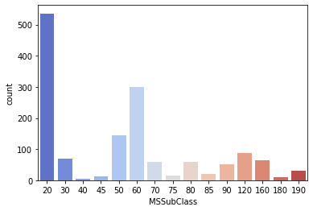

```python
sns.countplot('MSSubClass',data=df1,palette="coolwarm")
```

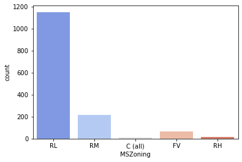

```python
sns.countplot('MSZoning',data=df1,palette="coolwarm")
```

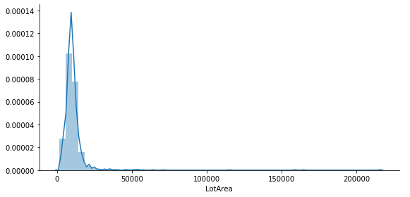

```python
plt.figure(figsize=(12,6))
g=sns.FacetGrid(df1,height=4, aspect=2)#width=h*a hue='MSZoning',
g.map(sns.distplot,'LotArea').add_legend()#加标签
plt.show()
```

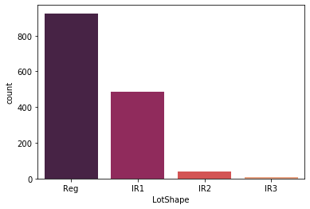

```python
sns.countplot('LotShape',data=df1,palette="rocket")
```

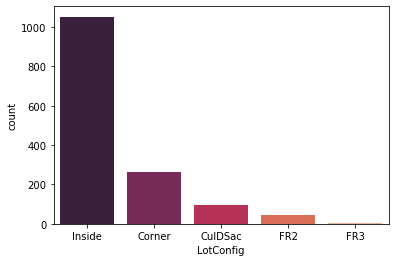

```python
sns.countplot('LotConfig',data=df1,palette="rocket",order = df1['LotConfig'].value_counts().index)
```

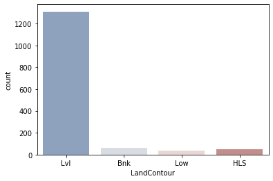

```python
sns.countplot('LandContour',data=df1,palette="vlag")
```

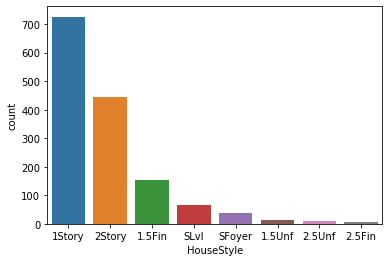

```python
sns.countplot('HouseStyle',data=df1,order = df1['HouseStyle'].value_counts().index)
```

### House surrounding environment

```python
df2=df[['Id','LotFrontage', 'Street','Alley','Neighborhood', 'Condition1', 'Condition2']]
```

```python
df2.head()
```

|  | Id | LotFrontage | Street | Alley | Neighborhood | Condition1 | Condition2 |
| --- | --- | --- | --- | --- | --- | --- | --- |
| 0 | 1 | 65.0 | Pave | NaN | CollgCr | Norm | Norm |
| 1 | 2 | 80.0 | Pave | NaN | Veenker | Feedr | Norm |
| 2 | 3 | 68.0 | Pave | NaN | CollgCr | Norm | Norm |
| 3 | 4 | 60.0 | Pave | NaN | Crawfor | Norm | Norm |
| 4 | 5 | 84.0 | Pave | NaN | NoRidge | Norm | Norm |

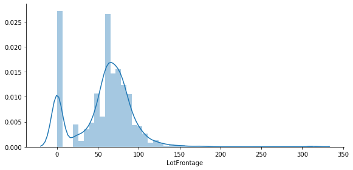

```python
g=sns.FacetGrid(df2,height=4, aspect=2)#width=h*a hue='MSZoning',
g.map(sns.distplot,'LotFrontage').add_legend()
```

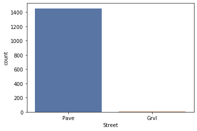

```python
sns.countplot('Street',data=df2,palette="deep")
```

### All the evaluation indices

```python
df3=df[['OverallQual', 'OverallCond','ExterQual', 'ExterCond', 'BsmtQual','BsmtCond', 'BsmtExposure', 'HeatingQC' ,'KitchenQual', 'GarageQual','GarageCond','PoolQC','Fence']]
```

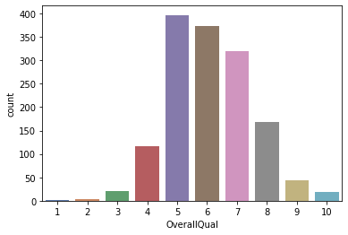

```python
sns.countplot('OverallQual',data=df3,palette="deep")
```

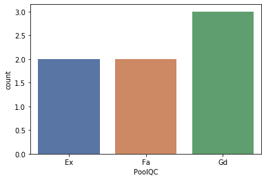

```python
sns.countplot('PoolQC',data=df3,palette="deep")
```

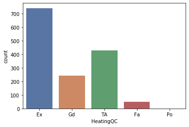

```python
sns.countplot( 'HeatingQC',data=df3,palette="deep")
```

### Time of Construction

```python
df4=df[['Id','YearBuilt', 'YearRemodAdd','GarageYrBlt','SalePrice']]
```

```python
df4.head()
```

|  | Id | YearBuilt | YearRemodAdd | GarageYrBlt | SalePrice |
| --- | --- | --- | --- | --- | --- |
| 0 | 1 | 2003 | 2003 | 2003.0 | 208500 |
| 1 | 2 | 1976 | 1976 | 1976.0 | 181500 |
| 2 | 3 | 2001 | 2002 | 2001.0 | 223500 |
| 3 | 4 | 1915 | 1970 | 1998.0 | 140000 |
| 4 | 5 | 2000 | 2000 | 2000.0 | 250000 |

### Sales data

```python
df5=df[['Id', 'MoSold', 'YrSold', 'SaleType','SaleCondition', 'SalePrice']]
```

```python
df5.head()
```

|  | Id | MoSold | YrSold | SaleType | SaleCondition | SalePrice |
| --- | --- | --- | --- | --- | --- | --- |
| 0 | 1 | 2 | 2008 | WD | Normal | 208500 |
| 1 | 2 | 5 | 2007 | WD | Normal | 181500 |
| 2 | 3 | 9 | 2008 | WD | Normal | 223500 |
| 3 | 4 | 2 | 2006 | WD | Abnorml | 140000 |
| 4 | 5 | 12 | 2008 | WD | Normal | 250000 |

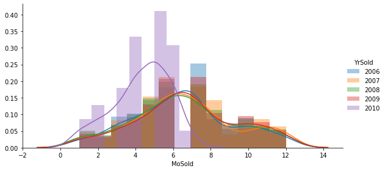

```python
plt.figure(figsize=(12,6))
g=sns.FacetGrid(df5,hue= 'YrSold',height=4, aspect=2)#width=h*a
g.map(sns.distplot,'MoSold').add_legend()#加标签
plt.show()
```

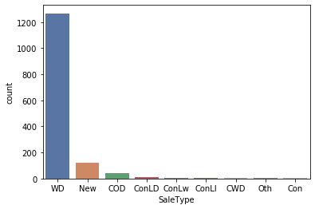

```python
sns.countplot('SaleType',data=df5,palette="deep",order = df5['SaleType'].value_counts().index)
```

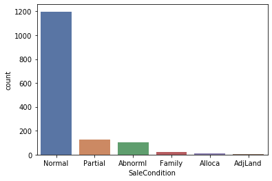

```python
sns.countplot('SaleCondition',data=df5,palette="deep",order = df5['SaleCondition'].value_counts().index)
```

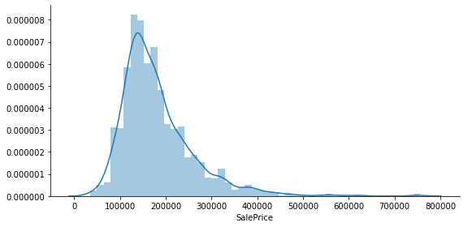

```python
g=sns.FacetGrid(df5,height=4, aspect=2)#width=h*a
g.map(sns.distplot,'SalePrice').add_legend()
```

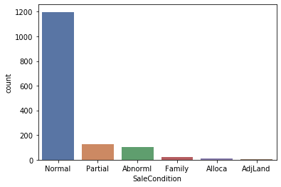

```python
sns.countplot('SaleCondition',data=df5,palette="deep",order = df5['SaleCondition'].value_counts().index)
```

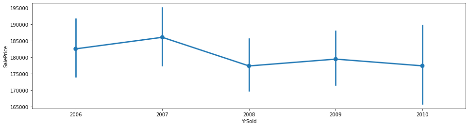

```python
plt.figure(figsize=(16,4))
sns.pointplot(x='YrSold',y='SalePrice',data=df)# average price
plt.show()
```

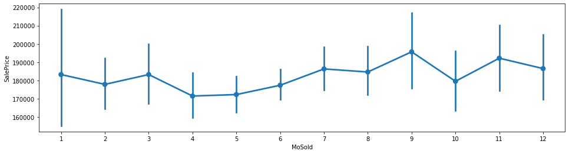

```python
plt.figure(figsize=(16,4))
sns.pointplot(x='MoSold',y='SalePrice',data=df)# average price
plt.show()
```

```python
bt = df5[['MoSold', 'YrSold', 'SaleType','SaleCondition', 'SalePrice']]
bt=bt.groupby(['MoSold']).size().reset_index()
#bt=DataFrame(bt,index=['Non-Travel-N', 'Non-Travel-Y', 'Travel_Frequently-N', 'Travel_Frequently-Y','Travel_Rarely-N','Travel_Rarely-Y'],columns=("BusinessTravel","Attrition",'count'))
bt.rename(columns={0:'Count'},index={0:'Jan',1:'Feb', 2:'Mar', 3:'Apr',4:'May',5:'June',
                                    6:'July',7:'Aug',8:'Sep',9:'Oct',10:'Nov',11:'Dec'},inplace=True)#
bt
```

|  | MoSold | Count |
| --- | --- | --- |
| Jan | 1 | 58 |
| Feb | 2 | 52 |
| Mar | 3 | 106 |
| Apr | 4 | 141 |
| May | 5 | 204 |
| June | 6 | 253 |
| July | 7 | 234 |
| Aug | 8 | 122 |
| Sep | 9 | 63 |
| Oct | 10 | 89 |
| Nov | 11 | 79 |
| Dec | 12 | 59 |

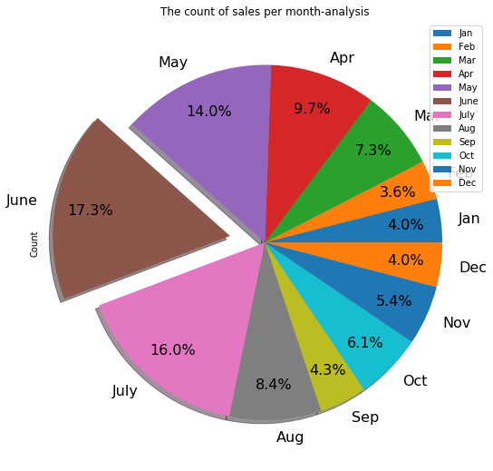

```python
bt.plot(kind='pie',y='Count',autopct='%1.1f%%',figsize=(9,9),title='The count of sales per month-analysis',
        fontsize=16,explode=[0,0,0,0,0,0.2,0,0,0,0,0,0],pctdistance=0.8,shadow=True)
```

### Analysis of the different components of the house

1.Roof: RoofStyle, RoofMatl 2.Exterior: Exterior1st, Exterior2nd,ExterQual, ExterCond

1. Masonry veneer: MasVnrType, MasVnrArea 4.Basement:BsmtQual, BsmtCond, BsmtExposure, BsmtFinType1,

   ```
              BsmtFinType2, BsmtFinSF1, BsmUnSF,TotalBsmtSF
   ```

2. Utilities:(Heating，Central Air, Electricity)Heating, HeatingQC,

   ```
               CentralAir, Electrical, Utilities
   ```

   6.Kitchen:Kitchen, KitchenQual 7.Garage: GarageType, GarageYrBlt, GarageFinish, GarageCars, GarageArea, GarageQual, GarageCond 8.Pool: PoolArea, PoolQC 9.Fireplace:FireQuplaces, FireplaceQu, 10.Fence: Fence
3. Miscellaneous: MiscFeature, MiscVal

```python
df6=df[["RoofStyle", "RoofMatl","Exterior1st", "Exterior2nd","ExterQual", "ExterCond","MasVnrType",
        "MasVnrArea","BsmtQual", "BsmtCond", "BsmtExposure", "BsmtFinType1",
 "BsmtFinType2", "BsmtFinSF1", "TotalBsmtSF","Heating", 'HeatingQC',
'CentralAir', 'Electrical', 'Utilities', 'KitchenQual','GarageType', 'GarageYrBlt','GarageFinish',
'GarageCars', 'GarageArea', 'GarageQual', 'GarageCond','PoolArea', 'PoolQC','Fireplaces','Fence',
'MiscFeature', 'MiscVal','SalePrice']]
```

## Select features & delete features

```python
'''df1=df[['MSSubClass', 'LotFrontage', 'LotArea', 'OverallQual',
       'OverallCond', 'YearBuilt', 'YearRemodAdd', 'MasVnrArea', 'BsmtFinSF1',
       'BsmtFinSF2', 'BsmtUnfSF', 'TotalBsmtSF', '1stFlrSF', '2ndFlrSF',
       'LowQualFinSF', 'GrLivArea', 'BsmtFullBath', 'BsmtHalfBath', 'FullBath',
       'HalfBath', 'BedroomAbvGr', 'KitchenAbvGr', 'TotRmsAbvGrd',
       'Fireplaces', 'GarageYrBlt', 'GarageCars', 'GarageArea', 'WoodDeckSF',
       'OpenPorchSF', 'EnclosedPorch', '3SsnPorch', 'ScreenPorch', 'PoolArea',
       'MiscVal', 'MoSold', 'YrSold', 'SalePrice']]'''
```

```
"df1=df[['MSSubClass', 'LotFrontage', 'LotArea', 'OverallQual',\n       'OverallCond', 'YearBuilt', 'YearRemodAdd', 'MasVnrArea', 'BsmtFinSF1',\n       'BsmtFinSF2', 'BsmtUnfSF', 'TotalBsmtSF', '1stFlrSF', '2ndFlrSF',\n       'LowQualFinSF', 'GrLivArea', 'BsmtFullBath', 'BsmtHalfBath', 'FullBath',\n…
```

```python
X_trained=df.copy()
X_trained.drop(['SalePrice'],axis=1,inplace=True)
Y_trained=df['SalePrice']
```

```python
#corr_mat=X_trained.corr(method='pearson')
#plt.figure(figsize=(30,20))
#sns.heatmap(corr_mat,vmax=1,square=True,annot=True,cmap='cubehelix')
```

### The frist time to drop

```python
df.describe().T
```

|  | count | mean | std | min | 25% | 50% | 75% | max |
| --- | --- | --- | --- | --- | --- | --- | --- | --- |
| Id | 1460.0 | 730.500000 | 421.610009 | 1.0 | 365.75 | 730.5 | 1095.25 | 1460.0 |
| MSSubClass | 1460.0 | 56.897260 | 42.300571 | 20.0 | 20.00 | 50.0 | 70.00 | 190.0 |
| LotFrontage | 1460.0 | 57.623288 | 34.664304 | 0.0 | 42.00 | 63.0 | 79.00 | 313.0 |
| LotArea | 1460.0 | 10516.828082 | 9981.264932 | 1300.0 | 7553.50 | 9478.5 | 11601.50 | 215245.0 |
| OverallQual | 1460.0 | 6.099315 | 1.382997 | 1.0 | 5.00 | 6.0 | 7.00 | 10.0 |
| OverallCond | 1460.0 | 5.575342 | 1.112799 | 1.0 | 5.00 | 5.0 | 6.00 | 9.0 |
| YearBuilt | 1460.0 | 1971.267808 | 30.202904 | 1872.0 | 1954.00 | 1973.0 | 2000.00 | 2010.0 |
| YearRemodAdd | 1460.0 | 1984.865753 | 20.645407 | 1950.0 | 1967.00 | 1994.0 | 2004.00 | 2010.0 |
| MasVnrArea | 1452.0 | 103.685262 | 181.066207 | 0.0 | 0.00 | 0.0 | 166.00 | 1600.0 |
| BsmtFinSF1 | 1460.0 | 443.639726 | 456.098091 | 0.0 | 0.00 | 383.5 | 712.25 | 5644.0 |
| BsmtFinSF2 | 1460.0 | 46.549315 | 161.319273 | 0.0 | 0.00 | 0.0 | 0.00 | 1474.0 |
| BsmtUnfSF | 1460.0 | 567.240411 | 441.866955 | 0.0 | 223.00 | 477.5 | 808.00 | 2336.0 |
| TotalBsmtSF | 1460.0 | 1057.429452 | 438.705324 | 0.0 | 795.75 | 991.5 | 1298.25 | 6110.0 |
| 1stFlrSF | 1460.0 | 1162.626712 | 386.587738 | 334.0 | 882.00 | 1087.0 | 1391.25 | 4692.0 |
| 2ndFlrSF | 1460.0 | 346.992466 | 436.528436 | 0.0 | 0.00 | 0.0 | 728.00 | 2065.0 |
| LowQualFinSF | 1460.0 | 5.844521 | 48.623081 | 0.0 | 0.00 | 0.0 | 0.00 | 572.0 |
| GrLivArea | 1460.0 | 1515.463699 | 525.480383 | 334.0 | 1129.50 | 1464.0 | 1776.75 | 5642.0 |
| BsmtFullBath | 1460.0 | 0.425342 | 0.518911 | 0.0 | 0.00 | 0.0 | 1.00 | 3.0 |
| BsmtHalfBath | 1460.0 | 0.057534 | 0.238753 | 0.0 | 0.00 | 0.0 | 0.00 | 2.0 |
| FullBath | 1460.0 | 1.565068 | 0.550916 | 0.0 | 1.00 | 2.0 | 2.00 | 3.0 |
| HalfBath | 1460.0 | 0.382877 | 0.502885 | 0.0 | 0.00 | 0.0 | 1.00 | 2.0 |
| BedroomAbvGr | 1460.0 | 2.866438 | 0.815778 | 0.0 | 2.00 | 3.0 | 3.00 | 8.0 |
| KitchenAbvGr | 1460.0 | 1.046575 | 0.220338 | 0.0 | 1.00 | 1.0 | 1.00 | 3.0 |
| TotRmsAbvGrd | 1460.0 | 6.517808 | 1.625393 | 2.0 | 5.00 | 6.0 | 7.00 | 14.0 |
| Fireplaces | 1460.0 | 0.613014 | 0.644666 | 0.0 | 0.00 | 1.0 | 1.00 | 3.0 |
| GarageYrBlt | 1379.0 | 1978.506164 | 24.689725 | 1900.0 | 1961.00 | 1980.0 | 2002.00 | 2010.0 |
| GarageCars | 1460.0 | 1.767123 | 0.747315 | 0.0 | 1.00 | 2.0 | 2.00 | 4.0 |
| GarageArea | 1460.0 | 472.980137 | 213.804841 | 0.0 | 334.50 | 480.0 | 576.00 | 1418.0 |
| WoodDeckSF | 1460.0 | 94.244521 | 125.338794 | 0.0 | 0.00 | 0.0 | 168.00 | 857.0 |
| OpenPorchSF | 1460.0 | 46.660274 | 66.256028 | 0.0 | 0.00 | 25.0 | 68.00 | 547.0 |
| EnclosedPorch | 1460.0 | 21.954110 | 61.119149 | 0.0 | 0.00 | 0.0 | 0.00 | 552.0 |
| 3SsnPorch | 1460.0 | 3.409589 | 29.317331 | 0.0 | 0.00 | 0.0 | 0.00 | 508.0 |
| ScreenPorch | 1460.0 | 15.060959 | 55.757415 | 0.0 | 0.00 | 0.0 | 0.00 | 480.0 |
| PoolArea | 1460.0 | 2.758904 | 40.177307 | 0.0 | 0.00 | 0.0 | 0.00 | 738.0 |
| MiscVal | 1460.0 | 43.489041 | 496.123024 | 0.0 | 0.00 | 0.0 | 0.00 | 15500.0 |
| MoSold | 1460.0 | 6.321918 | 2.703626 | 1.0 | 5.00 | 6.0 | 8.00 | 12.0 |
| YrSold | 1460.0 | 2007.815753 | 1.328095 | 2006.0 | 2007.00 | 2008.0 | 2009.00 | 2010.0 |
| SalePrice | 1460.0 | 180921.195890 | 79442.502883 | 34900.0 | 129975.00 | 163000.0 | 214000.00 | 755000.0 |

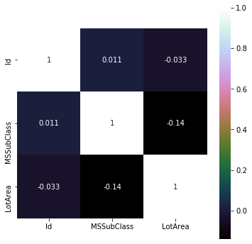

```python
corr_mat=df1.corr(method='pearson')
plt.figure(figsize=(6,6))
sns.heatmap(corr_mat,vmax=1,square=True,annot=True,cmap='cubehelix')
```

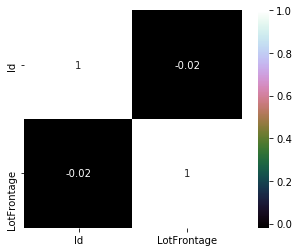

```python
corr_mat=df2.corr(method='pearson')
sns.heatmap(corr_mat,vmax=1,square=True,annot=True,cmap='cubehelix')
```

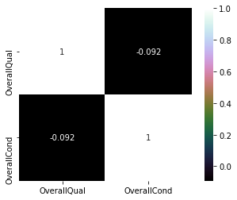

```python
corr_mat=df3.corr(method='pearson')
sns.heatmap(corr_mat,vmax=1,square=True,annot=True,cmap='cubehelix')
```

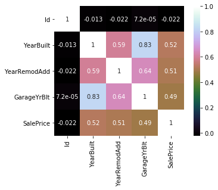

```python
corr_mat=df4.corr(method='pearson')
sns.heatmap(corr_mat,vmax=1,square=True,annot=True,cmap='cubehelix')
```

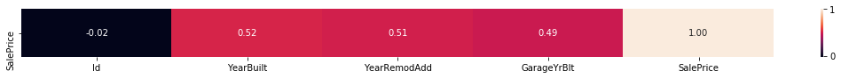

```python
num=df4.select_dtypes(exclude='object')
numcorr=num.corr()
f,ax=plt.subplots(figsize=(19,1))#set figure size
sns.heatmap(numcorr.sort_values(by='SalePrice',ascending=False).head(1),annot= True,fmt=".2f")
plt.show()
```

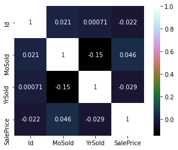

```python
corr_mat=df5.corr(method='pearson')
sns.heatmap(corr_mat,vmax=1,square=True,annot=True,cmap='cubehelix')
```

### The second time to drop

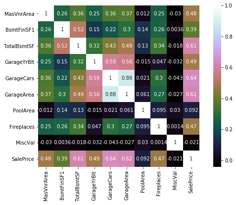

```python
corr_mat=df6.corr(method='pearson')
plt.figure(figsize=(10,6))
sns.heatmap(corr_mat,vmax=1,square=True,annot=True,cmap='cubehelix')
```

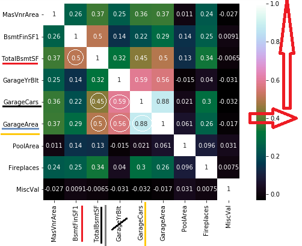

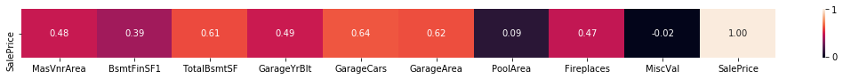

```python
num=df6.select_dtypes(exclude='object')
numcorr=num.corr()
f,ax=plt.subplots(figsize=(19,1))#set figure size
sns.heatmap(numcorr.sort_values(by='SalePrice',ascending=False).head(1),annot= True,fmt=".2f")
plt.show()
```

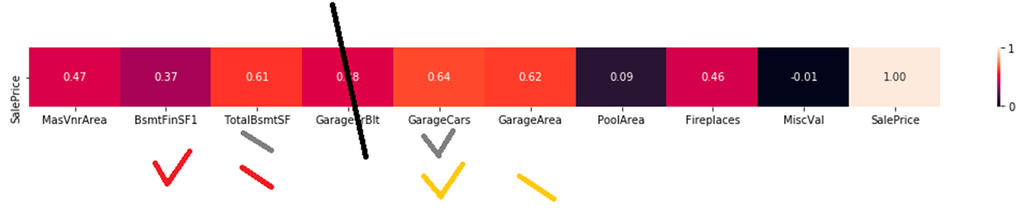

## Before data putting into model

### Select indpendent varibales and dependent varibales

```python
df2=df[['MSZoning','Street','LotShape','SaleType', 'SaleCondition','MSSubClass', 'LotFrontage', 'LotArea', 'OverallQual',
       'OverallCond', 'MasVnrArea', 'BsmtFinSF1', 'LandContour', 'Utilities','LotConfig',
        'LandSlope', 'Neighborhood', 'Condition1', 'HouseStyle','RoofStyle',
       'BsmtFinSF2', 'BsmtUnfSF', 'TotalBsmtSF', '1stFlrSF', '2ndFlrSF',
       'LowQualFinSF', 'GrLivArea', 'BsmtFullBath', 'BsmtHalfBath', 'FullBath',
       'HalfBath', 'BedroomAbvGr', 'KitchenAbvGr', 'TotRmsAbvGrd',
       'Fireplaces','GarageCars', 'GarageArea', 'WoodDeckSF',
       'OpenPorchSF', 'EnclosedPorch', '3SsnPorch', 'ScreenPorch', 'PoolArea',
       'MiscVal', 'MoSold', 'YrSold', 'SalePrice','ExterQual', 'ExterCond', 'Foundation',
        'Heating', 'HeatingQC', 'CentralAir', 'Electrical', 'KitchenQual', 'Functional', 'FireplaceQu', 'GarageType'
]]
df2=df2.dropna(axis=0)
```

```python
df2.shape
```

```
(1451, 58)
```

### Feature Engineering

```python
train=pd.get_dummies(df2)
```

```python
train.shape
```

```
(1451, 179)
```

```python
train.head()
```

|  | MSSubClass | LotFrontage | LotArea | OverallQual | OverallCond | MasVnrArea | BsmtFinSF1 | BsmtFinSF2 | BsmtUnfSF | TotalBsmtSF | 1stFlrSF | 2ndFlrSF | LowQualFinSF | GrLivArea | BsmtFullBath | BsmtHalfBath | FullBath | HalfBath | BedroomAbvGr | KitchenAbvGr | TotRmsAbvGrd | Fireplaces | GarageCars | GarageArea | WoodDeckSF | OpenPorchSF | EnclosedPorch | 3SsnPorch | ScreenPorch | … |
| --- | --- | --- | --- | --- | --- | --- | --- | --- | --- | --- | --- | --- | --- | --- | --- | --- | --- | --- | --- | --- | --- | --- | --- | --- | --- | --- | --- | --- | --- | --- |
| 0 | 60 | 65.0 | 8450 | 7 | 5 | 196.0 | 706 | 0 | 150 | 856 | 856 | 854 | 0 | 1710 | 1 | 0 | 2 | 1 | 3 | 1 | 8 | 0 | 2 | 548 | 0 | 61 | 0 | 0 | 0 | … |
| 1 | 20 | 80.0 | 9600 | 6 | 8 | 0.0 | 978 | 0 | 284 | 1262 | 1262 | 0 | 0 | 1262 | 0 | 1 | 2 | 0 | 3 | 1 | 6 | 1 | 2 | 460 | 298 | 0 | 0 | 0 | 0 | … |
| 2 | 60 | 68.0 | 11250 | 7 | 5 | 162.0 | 486 | 0 | 434 | 920 | 920 | 866 | 0 | 1786 | 1 | 0 | 2 | 1 | 3 | 1 | 6 | 1 | 2 | 608 | 0 | 42 | 0 | 0 | 0 | … |
| 3 | 70 | 60.0 | 9550 | 7 | 5 | 0.0 | 216 | 0 | 540 | 756 | 961 | 756 | 0 | 1717 | 1 | 0 | 1 | 0 | 3 | 1 | 7 | 1 | 3 | 642 | 0 | 35 | 272 | 0 | 0 | … |
| 4 | 60 | 84.0 | 14260 | 8 | 5 | 350.0 | 655 | 0 | 490 | 1145 | 1145 | 1053 | 0 | 2198 | 1 | 0 | 2 | 1 | 4 | 1 | 9 | 1 | 3 | 836 | 192 | 84 | 0 | 0 | 0 | … |

```python
train = pd.get_dummies(train, columns=['MSSubClass','MoSold','OverallQual','OverallCond',
       'LowQualFinSF', 'BedroomAbvGr', 'KitchenAbvGr', 'TotRmsAbvGrd','MoSold', 'YrSold'])
train.shape
```

```
(1451, 281)
```

```python
train.head()
```

|  | LotFrontage | LotArea | MasVnrArea | BsmtFinSF1 | BsmtFinSF2 | BsmtUnfSF | TotalBsmtSF | 1stFlrSF | 2ndFlrSF | GrLivArea | BsmtFullBath | BsmtHalfBath | FullBath | HalfBath | Fireplaces | GarageCars | GarageArea | WoodDeckSF | OpenPorchSF | EnclosedPorch | 3SsnPorch | ScreenPorch | PoolArea | MiscVal | SalePrice | MSZoning_C (all) | MSZoning_FV | MSZoning_RH | MSZoning_RL | … |
| --- | --- | --- | --- | --- | --- | --- | --- | --- | --- | --- | --- | --- | --- | --- | --- | --- | --- | --- | --- | --- | --- | --- | --- | --- | --- | --- | --- | --- | --- | --- |
| 0 | 65.0 | 8450 | 196.0 | 706 | 0 | 150 | 856 | 856 | 854 | 1710 | 1 | 0 | 2 | 1 | 0 | 2 | 548 | 0 | 61 | 0 | 0 | 0 | 0 | 0 | 208500 | 0 | 0 | 0 | 1 | … |
| 1 | 80.0 | 9600 | 0.0 | 978 | 0 | 284 | 1262 | 1262 | 0 | 1262 | 0 | 1 | 2 | 0 | 1 | 2 | 460 | 298 | 0 | 0 | 0 | 0 | 0 | 0 | 181500 | 0 | 0 | 0 | 1 | … |
| 2 | 68.0 | 11250 | 162.0 | 486 | 0 | 434 | 920 | 920 | 866 | 1786 | 1 | 0 | 2 | 1 | 1 | 2 | 608 | 0 | 42 | 0 | 0 | 0 | 0 | 0 | 223500 | 0 | 0 | 0 | 1 | … |
| 3 | 60.0 | 9550 | 0.0 | 216 | 0 | 540 | 756 | 961 | 756 | 1717 | 1 | 0 | 1 | 0 | 1 | 3 | 642 | 0 | 35 | 272 | 0 | 0 | 0 | 0 | 140000 | 0 | 0 | 0 | 1 | … |
| 4 | 84.0 | 14260 | 350.0 | 655 | 0 | 490 | 1145 | 1145 | 1053 | 2198 | 1 | 0 | 2 | 1 | 1 | 3 | 836 | 192 | 84 | 0 | 0 | 0 | 0 | 0 | 250000 | 0 | 0 | 0 | 1 | … |

```python
print(train.columns)
```

```
Index(['LotFrontage', 'LotArea', 'MasVnrArea', 'BsmtFinSF1', 'BsmtFinSF2',
       'BsmtUnfSF', 'TotalBsmtSF', '1stFlrSF', '2ndFlrSF', 'GrLivArea',
       ...
       'MoSold_8', 'MoSold_9', 'MoSold_10', 'MoSold_11', 'MoSold_12',
       'YrSold_2006', 'YrSold_2007', 'YrSold_2008', 'YrSold_2009',
       'YrSold_2010'],
      dtype='object', length=281)
```

```python
X_trained=train.copy()
X_trained.drop(['SalePrice'],axis=1,inplace=True)
Y_trained=train['SalePrice'].values
```

```python
#X= X_trained.iloc[:,:].values
#type(X)
#X.shape
#X[0]
```

```python
#X[:,0]
#X[:,1]#Show the first series
#X[:,2]
#for i in range(4):
#    print(X[:,i])
```

```python
#for i in range(3):
#    dummy=pd.get_dummies(X[:,0])
#    dummy=np.asarray(dummy)
#    X= np.concatenate((X,dummy),axis=1)
#    X=np.delete(X,0,1)#delete 0 position,axis=1
```

```python
#X[0]
```

### Standardization & Split

```python
#X= X_trained.iloc[:,:].values
#Y= Y_trained.iloc[:,:].values
```

```python
from sklearn.preprocessing import StandardScaler
```

```python
from sklearn.model_selection import train_test_split
X= X_trained
y= Y_trained
x_trains, x_validation, y_trains, y_validation = train_test_split(X, y, test_size=0.2, random_state=0)
```

```python
#number_of_samples = len(X)
#np.random.seed(0)
#num_training_samples = int(number_of_samples*0.80)
#random_indices = np.random.permutation(number_of_samples)
# Split the data into training/testing(validation) sets
#x_trains = X[random_indices[:num_training_samples]]
#y_trains=Y[random_indices[:num_training_samples]]

#x_validation=X[random_indices[num_training_samples:]]
#y_validation=Y[random_indices[num_training_samples:]]
```

```python
x_validation.shape
```

```
(291, 280)
```

```python
y_validation.shape
```

```
(291,)
```

```python
scaler = StandardScaler()
# Fit on training set only.
scaler.fit(x_trains)
# Apply transform to both thvfe training set and the test set.
x_trains = scaler.transform(x_trains)
x_validation = scaler.transform(x_validation)
```

```python
x_validation.shape
```

```
(291, 280)
```

import pandas as pd from sklearn import preprocessing

x = df.values #returns a numpy array

min_max_scaler = preprocessing.MinMaxScaler()

x_scaled = min_max_scaler.fit_transform(x)

df = pd.DataFrame(x_scaled)

```python
from sklearn.decomposition import PCA
#Make an instance of the Model
pca = PCA(.95)
```

```python
pca.fit(x_trains)
```

```
PCA(copy=True, iterated_power='auto', n_components=0.95, random_state=None,
    svd_solver='auto', tol=0.0, whiten=False)
```

```python
x_trains = pca.transform(x_trains)
x_validation = pca.transform(x_validation)
```

```python
x_validation.shape
```

```
(291, 167)
```

```python
x_trains
```

```
array([[ 2.23952991, -2.25012686, -0.27232126, ...,  0.37865113,
        -0.00714348,  0.04138146],
       [ 1.45199927, -1.93999602, -1.9190256 , ..., -0.52190078,
         0.61486181,  0.06483842],
       [-4.43317183, -2.31629354,  0.47796961, ..., -0.13270612,
         1.30284569, -0.64516175],
       ...,
       [-1.26190657,  0.15048893,  0.55761168, ..., -0.45225514,
        -0.52795684, -0.74214948],
       [-0.94768693, -3.82312229,  1.31325693, ..., -0.2173204 ,
         0.35233258,  0.28413855],
       [ 1.08000888,  2.80264821, -4.99101665, ..., -0.73428518,
        -0.27803631, -1.05899211]])
```

```python
x_validation.shape
```

```
(291, 167)
```

## Multiple Linear Regression Model

```
Coefficients:
 [ 1.80674501e+04  2.94385933e+03  8.55922204e+03 -1.02335718e+03
 -1.50273283e+03 -3.77491744e+03  2.48791858e+03  3.58196196e+03
  2.32064850e+03 -4.97292915e+03 -7.85492380e+02 -7.60409637e+02
 -3.01370669e+03 -1.82978069e+03 -9.23933978e+01  5.63341465e+02
  4.09218027e+02 -1.27961342e+03 -9.23829441e+02 -1.20522237e+03
  3.77409532e+03 -8.20038956e+02 -2.52054639e+02 -8.12709828e+02
  2.57182902e+02  7.31996525e+02 -1.18412441e+03 -2.43084044e+03
  2.11747373e+02  6.48726130e+02 -3.25503979e+02  8.11059036e+02
  1.51856730e+03  3.76212467e+02  2.09421268e+03 -1.70065558e+03
  1.35764945e+03 -1.08635052e+03 -2.58418364e+03  1.76958247e+03
  2.50714339e+03  1.00814017e+03 -1.32115982e+03  7.14079772e+02
  3.02959241e+02 -2.43351158e+03  2.87012527e+03  6.20123241e+00
  1.45150133e+02 -1.99955286e+03  1.02693153e+03 -3.70543089e+02
  3.49853233e+02 -4.20383048e+02 -3.08509978e+02  8.01925229e+01
  3.60066113e+03 -3.14410146e+03 -2.22645911e+02 -1.96123196e+03
 -1.21343393e+03 -1.59193502e+03  1.09836778e+03 -8.32148641e+02
 -1.85396160e+02 -7.42046299e+02 -1.42617845e+03 -2.14822833e+03
  7.91374411e+02 -8.45796735e+02 -2.64689408e+02  7.73365147e+02
  9.23658885e+02  1.16440002e+03  1.20391896e+03  1.24753196e+03
  1.38198897e+03  8.45040780e+02 -4.19417480e+02 -7.70056122e+02
  2.78879111e+03  9.47748698e+02 -3.84451700e+01 -2.34220629e+03
  2.65776168e+01 -1.79042288e+03 -9.42965742e+02  4.62936889e+02
  3.86865312e+02 -1.22428003e+03  6.97493585e+02  2.18463948e+03
  1.36531576e+03  1.66570291e+03 -4.12469444e+02 -7.77996036e+01
  2.54126223e+03 -1.22236805e+03  1.54557853e+03 -1.19193138e+03
 -1.28850085e+03  1.27877011e+03 -1.88502917e+03 -3.94638801e+02
 -7.32859092e+02 -1.56153774e+03  6.89252992e+02 -1.66325151e+03
 -1.20554368e+03  9.30901650e+02  7.74483702e+02 -6.22902772e+02
  2.55181407e+03 -3.45586845e+03  2.70014752e+03  5.53860303e+02
  4.82942213e+03  2.28046930e+03  4.69479345e+02  1.08416817e+03
  2.70505659e+02 -2.56378947e+03  1.31925375e+03  9.03820231e+02
 -3.12525214e+03  2.08012392e+03 -4.60920593e+02 -1.01543459e+03
  1.68351799e+03 -1.03158429e+03  2.45803344e+03  4.27880671e+02
  9.15007569e+02  8.92392203e+02 -8.19828707e+02  4.17339034e+02
  2.57020718e+02 -1.25697933e+03 -1.69065222e+03 -1.83368780e+03
 -1.08946695e+03  1.15060517e+02 -2.44507340e+03  2.66741243e+03
  8.18623151e+02  1.27700048e+03 -1.78353233e+02  1.72441543e+03
 -2.24111637e+03  3.35430091e+03 -9.24710214e+02 -4.98547575e+02
  3.63987244e+03 -1.52150258e+03  1.10091389e+02 -3.28605550e+03
  8.10717770e+02 -5.92538572e+02  1.25804258e+03  6.28071727e+02
  5.55896958e+02  3.57840337e+02  2.33096279e+03  3.60803871e+03
 -2.58571838e+03  1.68782270e+02  1.48847144e+03]
the intercept: 181207.64482758622
r squared : 0.8547570486196332
Mean Absolute Error: 19498.43754116801
Mean Squared Error: 762858294.3222979
Root Mean Squared Error: 27619.88946976975
(291, 167)
The number of validation data: (291,)
```

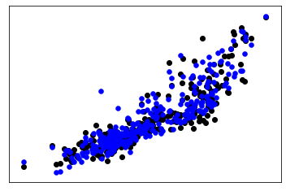

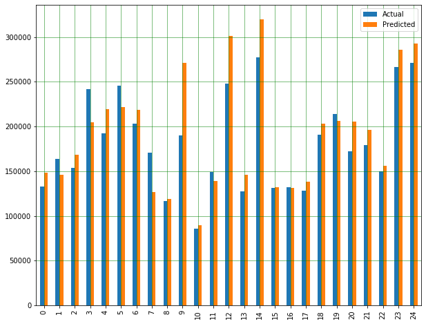

```python
import matplotlib.pyplot as plt
import numpy as np
from sklearn import datasets, linear_model
from sklearn.metrics import mean_squared_error, r2_score

# Create linear regression object
regr = linear_model.LinearRegression()

# Train the model using the training sets
regr.fit(x_trains, y_trains)

# Make predictions using the testing set
y_pred = regr.predict(x_validation)

# The coefficients(the slope)
print('Coefficients: \n', regr.coef_)
#To retrieve the intercept:
print("the intercept:",regr.intercept_)

from sklearn import metrics
from sklearn.metrics import accuracy_score, r2_score
print('r squared :',r2_score(y_validation,y_pred))
print('Mean Absolute Error:', metrics.mean_absolute_error(y_validation, y_pred))
print('Mean Squared Error:', metrics.mean_squared_error(y_validation, y_pred))
print('Root Mean Squared Error:', np.sqrt(metrics.mean_squared_error(y_validation, y_pred)))
print(x_validation.shape)
print('The number of validation data:',y_validation.shape)
# Plot outputs
plt.scatter(x_validation[:,0], y_validation,  color='black')#X_train[:,0]
plt.scatter(x_validation[:,0], y_pred, color='blue', linewidth=0.5)
#plt.plot(x_validation[:,0], y_pred, color='blue', linewidth=0.5)

plt.xticks(())
plt.yticks(())

plt.show()

# Plot outputs
ap=pd.DataFrame({'Actual': y_validation, 'Predicted': y_pred})
ap1=ap.head(25)
ap1.plot(kind='bar',figsize=(10,8))
plt.grid(which='major', linestyle='-', linewidth='0.5', color='green')
plt.grid(which='minor', linestyle=':', linewidth='0.5', color='black')
plt.show()
```

### Error

```python
def print_error_message(y_actual, y_predicted, data_prefix, model_name):
    error = 0
    for i in range(len(y_actual)):
        error += (abs(y_predicted[i]-y_actual[i])/y_actual[i])
    error_percent = error/len(y_actual) * 100
    print(f'{data_prefix} error = {round(error_percent, 2)}% in {model_name}')
print_error_message(y_validation, y_pred, "validation data", "Linear Regression")
```

```
validation data error = 11.6% in Linear Regression
```

## Random Forest Regression Model

```python
from sklearn.linear_model import LogisticRegression
from sklearn.model_selection import RandomizedSearchCV
from scipy.stats import uniform
from sklearn.ensemble import RandomForestRegressor
from sklearn.datasets import make_regression
'''params = {
    'n_estimators': [100, 500, 1000],
    'max_depth': [10, 20, 30, 40, 50, 60, 70, 80, 90, 100, None],
    'min_samples_leaf': [1,2,4],
    'min_samples_split': [2,5,10]
}

rf_random =RandomizedSearchCV(estimator = RandomForestRegressor(),
                              param_distributions = params, n_iter = 100, cv = 3,
                              verbose =2, random_state = 42, n_jobs = -1)
rf_random.fit(x_trains,y_trains)
rf_random.best_params_'''
#[Output will be the best parameters]
```

```
"params = {\n    'n_estimators': [100, 500, 1000],\n    'max_depth': [10, 20, 30, 40, 50, 60, 70, 80, 90, 100, None],\n    'min_samples_leaf': [1,2,4],\n    'min_samples_split': [2,5,10]\n}\n\nrf_random =RandomizedSearchCV(estimator = RandomForestRegressor(), \n                              param_di…
```

```python
regressor = RandomForestRegressor(
    n_estimators=100,
    min_samples_split=5,
    min_samples_leaf=1,
    max_depth=100)

regressor.fit(x_trains, y_trains)
y1_rfo = list(regressor.predict(x_trains))
y_pred = list(regressor.predict(x_validation))

print('r squared :',r2_score(y_validation,y_pred))
print_error_message(y_trains, y1_rfo, "Train", "Random Forest Regression")
print_error_message(y_validation, y_pred, "Validate", "Random Forest Regression")
```

```
r squared : 0.8809207356094688
Train error = 4.55% in Random Forest Regression
Validate error = 10.23% in Random Forest Regression
```

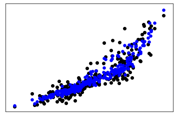

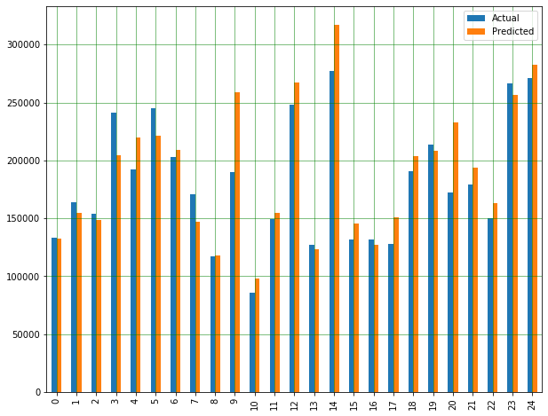

```python
# Plot outputs
plt.scatter(x_validation[:,0], y_validation,  color='black')#X_train[:,0]
plt.scatter(x_validation[:,0], y_pred, color='blue', linewidth=0.5)

plt.xticks(())
plt.yticks(())

plt.show()

# Plot outputs
ap=pd.DataFrame({'Actual': y_validation, 'Predicted': y_pred})
ap1=ap.head(25)
ap1.plot(kind='bar',figsize=(10,8))
plt.grid(which='major', linestyle='-', linewidth='0.5', color='green')
plt.grid(which='minor', linestyle=':', linewidth='0.5', color='black')
plt.show()
```

## Ridge Regression Model

```python
from sklearn.model_selection import GridSearchCV
from sklearn.linear_model import Ridge

params = { 'alpha': [i for i in range(1, 101)] }

ridge_reg = GridSearchCV(Ridge(), param_grid = params,
                        scoring = 'neg_mean_squared_error',
                        cv = 5)

ridge_reg.fit(x_trains, y_trains)
ridge_ytrain = ridge_reg.predict(x_trains)
y_pred = ridge_reg.predict(x_validation)

print(f'r2_square on validation set: {r2_score(y_validation, y_pred)}')
#print(f'The best value of Alpha is: {ridge_reg.best_params_}')
print_error_message(y_trains, ridge_ytrain, "Train", "Ridge Regression")
print_error_message(y_validation, y_pred, "Validate", "Ridge Regression")
```

```
r2_square on validation set: 0.8635134747160309
Train error = 9.73% in Ridge Regression
Validate error = 11.16% in Ridge Regression
```

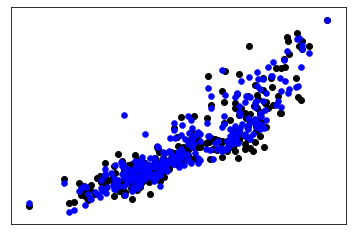

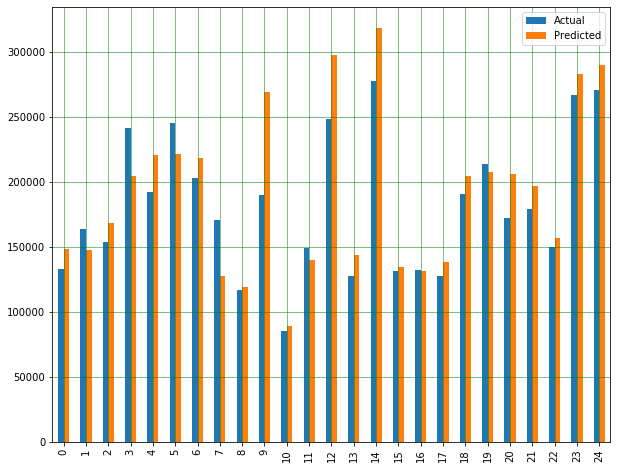

```python
# Plot outputs
plt.scatter(x_validation[:,0], y_validation,  color='black')#X_train[:,0]
plt.scatter(x_validation[:,0], y_pred, color='blue', linewidth=0.5)

plt.xticks(())
plt.yticks(())

plt.show()

# Plot outputs
ap=pd.DataFrame({'Actual': y_validation, 'Predicted': y_pred})
ap1=ap.head(25)
ap1.plot(kind='bar',figsize=(10,8))
plt.grid(which='major', linestyle='-', linewidth='0.5', color='green')
plt.grid(which='minor', linestyle=':', linewidth='0.5', color='black')
plt.show()
```

## Lasso Regression Model

```python
from sklearn.linear_model import LassoCV
from sklearn.linear_model import Lasso
from sklearn.model_selection import GridSearchCV
from sklearn.metrics import mean_squared_error  as mse
#@ignore_warnings(category=ConvergenceWarning)
def lasso_no_warnings(x, y):
    parameters = {'alpha': [0.0001, 0.0009, 0.001, 0.002, 0.002, 0.01, 0.1, 1, 10, 100]}
    lasso_reg = GridSearchCV(Lasso(), param_grid=parameters, scoring='neg_mean_squared_error', cv=5)
    return lasso_reg.fit(x, y)

lasso_reg = lasso_no_warnings(x_trains, y_trains)
lasso_ytrain = lasso_reg.predict(x_trains)
y_pred= lasso_reg.predict(x_validation)


#print(f'rmse on train set: {np.sqrt(mse(y_trains, lasso_ytrain))}')
#print(f'rmse on validation set: {np.sqrt(mse(y_validation, y_pred))}')
print(f'r2_square on validation set: {r2_score(y_validation, y_pred)}')
#print(f'The best value of Alpha is: {lasso_reg.best_params_}')
print_error_message(y_trains, lasso_ytrain, "Train", "Lasso Regression Model")
print_error_message(y_validation, y_pred, "Validate", "Lasso Regression Model")
```

[output not shown]

[output cut: 16 more lines]

```
r2_square on validation set: 0.8603948182644968
Train error = 9.81% in Lasso Regression Model
Validate error = 11.29% in Lasso Regression Model
```

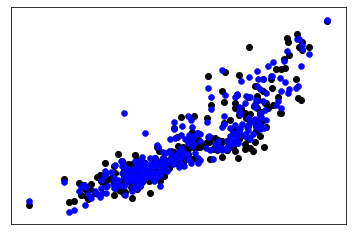

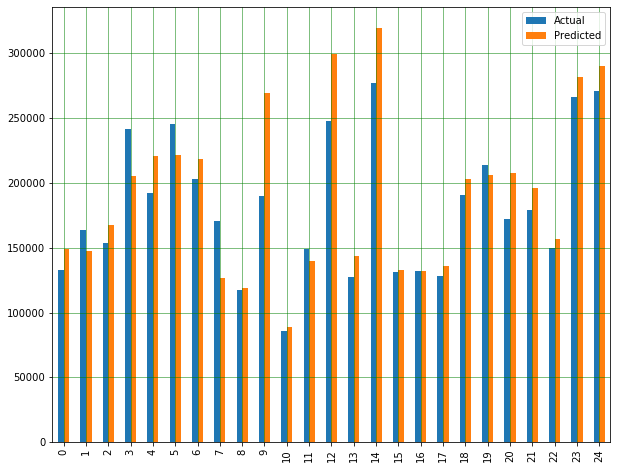

```python
# Plot outputs
plt.scatter(x_validation[:,0], y_validation,  color='black')#X_train[:,0]
plt.scatter(x_validation[:,0], y_pred, color='blue', linewidth=0.5)

plt.xticks(())
plt.yticks(())

plt.show()

# Plot outputs
ap=pd.DataFrame({'Actual': y_validation, 'Predicted': y_pred})
ap1=ap.head(25)
ap1.plot(kind='bar',figsize=(10,8))
plt.grid(which='major', linestyle='-', linewidth='0.5', color='green')
plt.grid(which='minor', linestyle=':', linewidth='0.5', color='black')
plt.show()
```

## Deal with test data

### Clean Test Data set

```python
dff=pd.read_csv("test.csv")
dff.shape
```

```
(1459, 80)
```

```python
dff['LotFrontage'].fillna(value=0,inplace=True)
dff['FireplaceQu'].fillna(value='No Info',inplace=True)
dff['GarageType'].fillna(value='No Garage',inplace=True)
```

```python
dff=dff[['MSZoning','Street','LotShape','SaleType', 'SaleCondition','MSSubClass', 'LotFrontage', 'LotArea', 'OverallQual',
       'OverallCond', 'MasVnrArea', 'BsmtFinSF1', 'LandContour', 'Utilities','LotConfig',
        'LandSlope', 'Neighborhood', 'Condition1', 'HouseStyle','RoofStyle',
       'BsmtFinSF2', 'BsmtUnfSF', 'TotalBsmtSF', '1stFlrSF', '2ndFlrSF',
       'LowQualFinSF', 'GrLivArea', 'BsmtFullBath', 'BsmtHalfBath', 'FullBath',
       'HalfBath', 'BedroomAbvGr', 'KitchenAbvGr', 'TotRmsAbvGrd',
       'Fireplaces','GarageCars', 'GarageArea', 'WoodDeckSF',
       'OpenPorchSF', 'EnclosedPorch', '3SsnPorch', 'ScreenPorch', 'PoolArea',
       'MiscVal', 'MoSold', 'YrSold', 'ExterQual', 'ExterCond', 'Foundation',
        'Heating', 'HeatingQC', 'CentralAir', 'Electrical', 'KitchenQual', 'Functional', 'FireplaceQu', 'GarageType',
         'YearBuilt', 'YearRemodAdd','PavedDrive'
]]
dff2=dff.dropna(axis=0)
X_test=dff2.copy()
X_test.shape
```

```
(1433, 60)
```

```python
X_test=pd.get_dummies(X_test)
X_test.shape
```

```
(1433, 178)
```

```python
X_test= pd.get_dummies(X_test, columns=['MSSubClass','MoSold','OverallQual','OverallCond',
       'LowQualFinSF', 'BedroomAbvGr', 'KitchenAbvGr', 'TotRmsAbvGrd','MoSold', 'YrSold'])
X_test.shape
```

```
(1433, 268)
```

```python
scaler = StandardScaler()
# Fit on training set only.
scaler.fit(X_test)
# Apply transform to both thvfe training set and the test set.
X_test = scaler.transform(X_test)
pca.fit(X_test)
X_test  = pca.transform(X_test)
X_test.shape
```

```
(1433, 167)
```

```python
X_test
```

```
array([[-3.42324308, -3.55185373, -0.68672189, ...,  0.88082057,
        -2.26961816,  0.55619251],
       [-0.06985833, -4.27171702,  0.16190761, ...,  0.12076321,
        -0.39269035, -0.83244733],
       [ 1.67468329,  1.10610521, -3.10791535, ...,  0.32247157,
        -0.2685253 , -0.28559991],
       ...,
       [-0.42936478, -2.54317976,  0.61455325, ..., -0.32358962,
         1.24922991,  0.59019344],
       [-2.77090987, -1.69310041, -2.2909805 , ..., -0.13468901,
         0.8537199 ,  0.45940708],
       [ 2.89234604,  1.55925769, -1.56677462, ..., -1.66388817,
        -0.17391382, -0.50698384]])
```

### Compare some independent values of training dataset to test dataset. You might choose the ones that you chose in Sprint 1.

In statistics, standardization is the process of putting different variables on the same scale. This process allows you to compare scores between different types of variables. Typically, to standardize variables, you calculate the mean and standard deviation for a variable. Then, for each observed value of the variable, you subtract the mean and divide by the standard deviation.

```python
import numpy as np
arr_mean = np.mean(df1) #Calculating mean
arr_std = np.std(df1,ddof=1) #And the standard deviation
newdata1=(df1-arr_mean )/arr_std # Conduct overall standardization

arr_mean = np.mean(dff) #Calculating mean
arr_std = np.std(dff,ddof=1) #And the standard deviation
newdata2=(dff-arr_mean )/arr_std # Conduct overall standardization
```

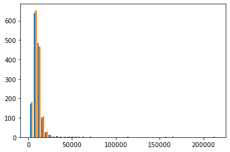

```python
#plt.hist([x, y], bins, label=['x', 'y'])
#plt.legend(loc='upper right')
#plt.show()
#from matplotlib import pyplot
x = df1['LotArea']
y = dff['LotArea']
# Make a multiple-histogram of data-sets with different length.
x_multi = [x,y]
plt.hist(x_multi,50, histtype='bar')
#plt.set_title('different sample sizes')
plt.show()
```

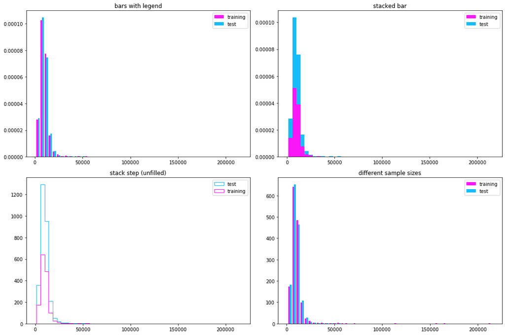

```python
#from matplotlib.pyplot import figure
#figure(num=None, figsize=(15, 10), dpi=80, facecolor='w', edgecolor='k')
#f, axs = plt.subplots(2,2,)
fig, axes = plt.subplots(nrows=2, ncols=2,figsize=(15,10))
ax0, ax1, ax2, ax3 = axes.flatten()
n_bins=50
x = df1['LotArea']
y = dff['LotArea']
x=[x,y]
#x = np.random.randn(1000, 3)
colors = ['#FB16F8', '#16BCFA']#,
ax0.hist(x, n_bins, normed=1, histtype='bar', color=colors, label=['training','test'])
ax0.legend(prop={'size': 10})
ax0.set_title('bars with legend')

ax1.hist(x, n_bins, normed=1, histtype='bar', stacked=True, color=colors,label=['training','test'])
ax1.legend(prop={'size': 10})
ax1.set_title('stacked bar')

ax2.hist(x, n_bins, histtype='step', stacked=True, fill=False,color=colors, label=['training','test'])
ax2.legend(prop={'size': 10})
ax2.set_title('stack step (unfilled)')

# Make a multiple-histogram of data-sets with different length.
#x_multi = [np.random.randn(n) for n in [10000, 5000, 2000]]
ax3.hist(x, n_bins, histtype='bar',color=colors,label=['training','test'])
ax3.legend(prop={'size': 10})
ax3.set_title('different sample sizes')

fig.tight_layout()
plt.show()
```

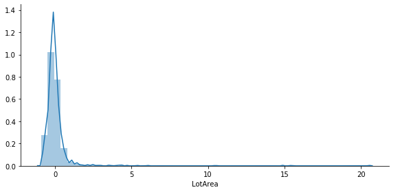

```python
plt.figure(figsize=(12,6))
g=sns.FacetGrid(newdata1,height=4, aspect=2)#width=h*a hue='MSZoning',
g.map(sns.distplot,'LotArea').add_legend()#加标签
plt.show()
```

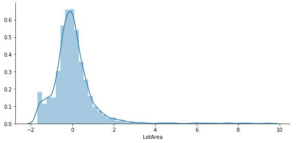

```python
plt.figure(figsize=(12,6))
g=sns.FacetGrid(newdata2,height=4, aspect=2)#width=h*a hue='MSZoning',
g.map(sns.distplot,'LotArea').add_legend()#加标签
plt.show()
```

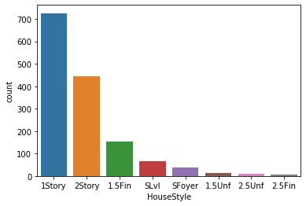

```python
sns.countplot('HouseStyle',data=df1,order = df1['HouseStyle'].value_counts().index)
```

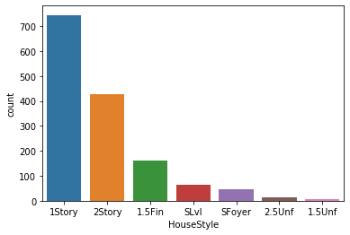

```python
sns.countplot('HouseStyle',data=dff,order = dff['HouseStyle'].value_counts().index)
```

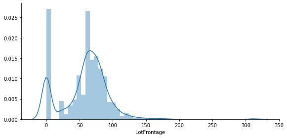

```python
g=sns.FacetGrid(df2,height=4, aspect=2)#width=h*a hue='MSZoning',
g.map(sns.distplot,'LotFrontage').add_legend()
```

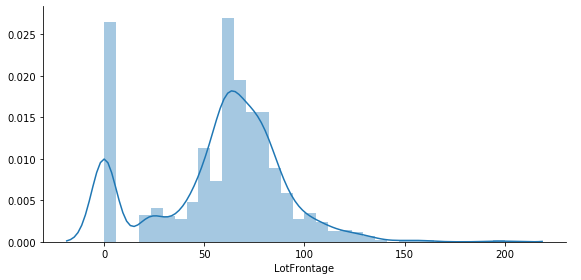

```python
g=sns.FacetGrid(dff,height=4, aspect=2)#width=h*a hue='MSZoning',
g.map(sns.distplot,'LotFrontage').add_legend()
```

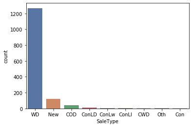

```python
sns.countplot('SaleType',data=df5,palette="deep",order = df5['SaleType'].value_counts().index)
```

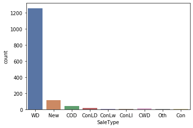

```python
sns.countplot('SaleType',data=dff,palette="deep",order = df5['SaleType'].value_counts().index)
```

```python
bt = dff[['MoSold', 'YrSold', 'SaleType','SaleCondition']]
bt=bt.groupby(['MoSold']).size().reset_index()
#bt=DataFrame(bt,index=['Non-Travel-N', 'Non-Travel-Y', 'Travel_Frequently-N', 'Travel_Frequently-Y','Travel_Rarely-N','Travel_Rarely-Y'],columns=("BusinessTravel","Attrition",'count'))
bt.rename(columns={0:'Count'},index={0:'Jan',1:'Feb', 2:'Mar', 3:'Apr',4:'May',5:'June',
                                    6:'July',7:'Aug',8:'Sep',9:'Oct',10:'Nov',11:'Dec'},inplace=True)#
bt
```

|  | MoSold | Count |
| --- | --- | --- |
| Jan | 1 | 64 |
| Feb | 2 | 81 |
| Mar | 3 | 126 |
| Apr | 4 | 138 |
| May | 5 | 190 |
| June | 6 | 250 |
| July | 7 | 212 |
| Aug | 8 | 111 |
| Sep | 9 | 95 |
| Oct | 10 | 84 |
| Nov | 11 | 63 |
| Dec | 12 | 45 |

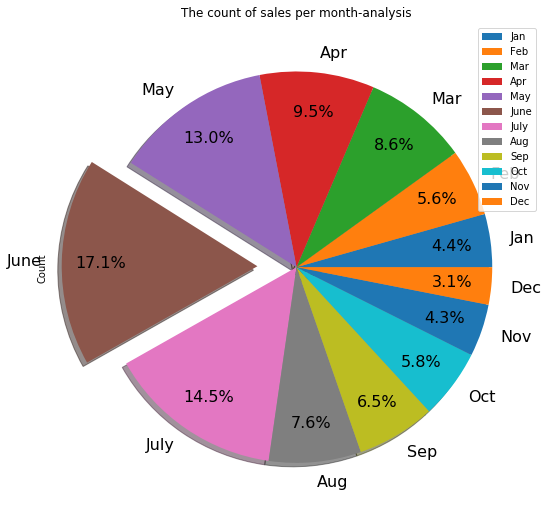

```python
bt.plot(kind='pie',y='Count',autopct='%1.1f%%',figsize=(9,9),title='The count of sales per month-analysis',
        fontsize=16,explode=[0,0,0,0,0,0.2,0,0,0,0,0,0],pctdistance=0.8,shadow=True)
```

### Put it into model

```python
y_test = list(regressor.predict(X_test))
```

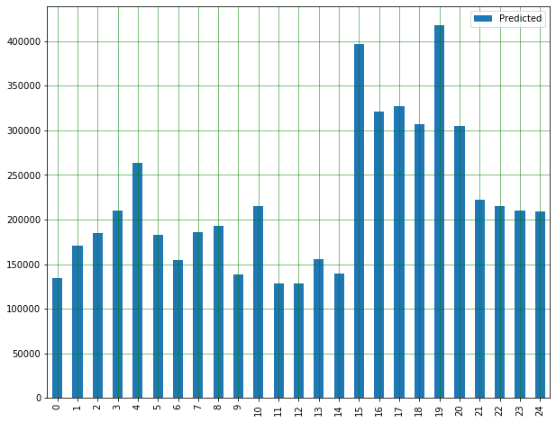

```python
ap=pd.DataFrame({'Predicted': y_test})
ap1=ap.head(25)
ap1.plot(kind='bar',figsize=(10,8))
plt.grid(which='major', linestyle='-', linewidth='0.5', color='green')
plt.grid(which='minor', linestyle=':', linewidth='0.5', color='black')
plt.show()
```

```python
import numpy as np
arr_mean = np.mean(ap) #Calculating mean
arr_std = np.std(ap,ddof=1) #And the standard deviation
ap2=(ap-arr_mean )/arr_std # Conduct overall standardization

arr_mean = np.mean(df) #Calculating mean
arr_std = np.std(df,ddof=1) #And the standard deviation
newdata3=(df-arr_mean )/arr_std # Conduct overall standardization
```

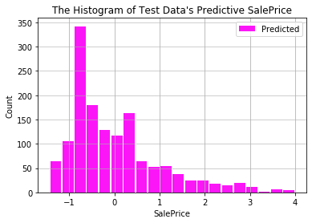

```python
ap2.plot.hist(grid=True, bins=20, rwidth=0.9,
                   color='#FB16F8')
plt.title('The Histogram of Test Data\'s Predictive SalePrice')
plt.xlabel('SalePrice')
plt.ylabel('Count')
plt.grid(axis='y', alpha=0.75)
```

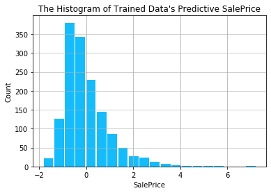

```python
newdata3['SalePrice'].plot.hist(grid=True, bins=20, rwidth=0.9,
                   color='#16BCFA')#'#607c8e'
plt.title('The Histogram of Trained Data\'s Predictive SalePrice')
plt.xlabel('SalePrice')
plt.ylabel('Count')
plt.grid(axis='y', alpha=0.75)
```

[figure not shown]

```python
fig, axes = plt.subplots(nrows=2, ncols=2,figsize=(15,10))
ax0, ax1, ax2, ax3 = axes.flatten()
n_bins=50
x = ap['Predicted']
y = df['SalePrice']
l=[x,y]
#x = np.random.randn(1000, 3)
colors = ['#FB16F8', '#16BCFA']#,
ax0.hist(l, n_bins, normed=1, histtype='bar', color=colors, label=['actual train/validation','predicted test'])
ax0.legend(prop={'size': 10})
ax0.set_title('bars with legend')

ax1.hist(l, n_bins, normed=1, histtype='bar', stacked=True, color=colors,label=['predicted test','actual train/validation'])
ax1.legend(prop={'size': 10})
ax1.set_title('stacked bar')

ax2.hist(l, n_bins, histtype='step', stacked=True, fill=False,color=colors, label=['actual train/validation','predicted test'])
ax2.legend(prop={'size': 10})
ax2.set_title('stack step (unfilled)')

# Make a multiple-histogram of data-sets with different length.
#x_multi = [np.random.randn(n) for n in [10000, 5000, 2000]]
ax3.hist(l, n_bins, histtype='bar',color=colors,label=['actual train/validation','predicted test'])
ax3.legend(prop={'size': 10})
ax3.set_title('different sample sizes')

fig.tight_layout()
plt.show()
```